# Installation

Two steps I had to do before beginning, is to install a cpp and a fortran compiler

`sudo apt-get install gfortran`

`sudo apt-get install g++`

After downloading and extracting the latest version of mbdyn (mbdyn-1.7.2), I faced two problems with the official instructions.

1 . `make install` didn't exactly work as planned as it required root priviliges.

running `sudo make install` seem to fix the problem

2 . The command `mbdyn` wasn't working , so I suspected it must be some kind of a path problem.

I added the below line to my `.bashrc`, and it worked.

`export PATH=${PATH}:/usr/local/mbdyn/bin/`

The `*.mov` files generated by `mbdyn` seemed to be a little messy to directly import through `pandas`.

I scraped off the whitespace at the beginning of each line through `sed`, and converted the `*.mov` files to `*.csv` using Libreoffice Calc, using space as a delimiter.

```python
import pandas as pd
import matplotlib.pyplot as plt
```

# Plot for free falling body

```python
df = pd.read_csv('free_body/free_falling_body.csv', header=None)
```

```python
x, y, z = (df.iloc[:, 1] , df.iloc[:, 2], df.iloc[:, 3])
```

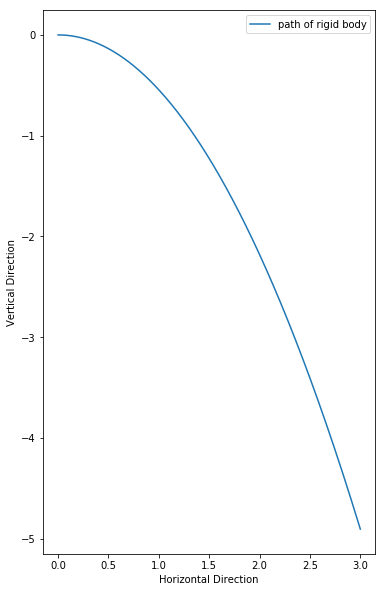

```python
plt.subplots(figsize=(6,10))

plt.gca().set_aspect('equal')
plt.plot(y, z, label = 'path of rigid body')
plt.legend()

plt.xlabel('Horizontal Direction')
plt.ylabel('Vertical Direction')

plt.show()
```

# Plot for simple pendulum

```python
df = pd.read_csv('pendulum/pendulum.csv', header=None)
```

```python
x, y, z = (df.iloc[:, 1] , df.iloc[:, 2], df.iloc[:, 3])
```

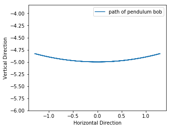

```python
plt.gca().set_aspect('equal')

plt.ylim(-1 + min(z), 1 + max(z))
plt.plot(x, z, label = 'path of pendulum bob')
plt.legend()

plt.xlabel('Horizontal Direction')
plt.ylabel('Vertical Direction')

plt.show()
```

# Rendering an animation

I tried rendering the simple case of a freely falling body, and ran into errors. Turns out it was an error in Blendyn, where each keyframe was being insterted at frame number 1. I've opened up a PR at #3. You can find the rendered video at

https://janga1997.github.io/janga1997.ogv